# New york ride

yybei

2022/2/18

# 1. Introduction

In this project,I’d like to focus on Spatial problem of space & time taxi ride demand and time consumption for each taxi trip in New York.

## Set up

```r
library(tidyverse)
library(sf)
library(lubridate)
library(tigris)
library(tidycensus)
library(viridis)
library(riem)
library(gridExtra)
library(knitr)
library(kableExtra)
library(caret)
library(RSocrata)
library(data.table)
library(pacman)
library(geosphere)
library(lubridate)
library(readr)
library(dplyr)
library(ggplot2)
library(gridExtra)
library(corrplot)
library(leaflet)
library(stringr)
library(rgdal)
library(mapview)
library(dplyr)
library(geodist)
library(lubridate)
library(tigris)
library(viridis)
library(riem)
library(gridExtra)
library(knitr)
library(mapview)
library(kableExtra)
library(RSocrata)

library(gifski)
library(RSocrata)
library(spatstat)
library(raster)
library(spdep)
library(FNN)
library(gganimate)


library(ggmap)
library(gmapsdistance)

plotTheme <- theme(
  plot.title =element_text(size=12),
  plot.subtitle = element_text(size=8),
  plot.caption = element_text(size = 6),
  axis.text.x = element_text(size = 10, angle = 45, hjust = 1),
  axis.text.y = element_text(size = 10),
  axis.title.y = element_text(size = 10),
  # Set the entire chart region to blank
  panel.background=element_blank(),
  plot.background=element_blank(),
  #panel.border=element_rect(colour="#F0F0F0"),
  # Format the grid
  panel.grid.major=element_line(colour="#D0D0D0",size=.2),
  axis.ticks=element_blank())

mapTheme <- theme(plot.title =element_text(size=12),
                  plot.subtitle = element_text(size=8),
                  plot.caption = element_text(size = 6),
                  axis.line=element_blank(),
                  axis.text.x=element_blank(),
                  axis.text.y=element_blank(),
                  axis.ticks=element_blank(),
                  axis.title.x=element_blank(),
                  axis.title.y=element_blank(),
                  panel.background=element_blank(),
                  panel.border=element_blank(),
                  panel.grid.major=element_line(colour = 'transparent'),
                  panel.grid.minor=element_blank(),
                  legend.direction = "vertical",
                  legend.position = "right",
                  plot.margin = margin(1, 1, 1, 1, 'cm'),
                  legend.key.height = unit(1, "cm"), legend.key.width = unit(0.2, "cm"))

palette5 <- c("#eff3ff","#bdd7e7","#6baed6","#3182bd","#08519c")
palette4 <- c("#D2FBD4","#92BCAB","#527D82","#123F5A")
palette2 <- c("#6baed6","#08519c")

options(tigris_class = "sf")
source("https://raw.githubusercontent.com/urbanSpatial/Public-Policy-Analytics-Landing/master/functions.r")
setwd("D:\\Spring-Penn\\Capstone\\in progress\\YebeiYao_NY_taxi-trip-duration-analysis")
```

# Load data

## Load census data

Considering taxi ride is a kind of commuting method, the commuting pattern of public transit should be potential factors to taxi trip time consumption and taxi demand around city. So I selected several features that should play an importance to the taxi trip for further model building.

Those features are census data like population in each census tract of travel time to work by different means of transport method. The race composition and house rent in each tract. Those features are likely to play great infection on taxi trip.

```r
# Install Census API Key
census_api_key("e79f3706b6d61249968c6ce88794f6f556e5bf3d", overwrite = TRUE)

# Import Census Info,especially commmuting data.
tracts16 <-
  get_acs(geography = "tract", variables = c("B08301_001", #Means Of Transportation To Work,total
                                             "B08301_002", #Means Of Transportation To Work,Car, truck, or van,
                                             "B08301_010", #Means Of Transportation To Work, public transit
                                             "B08301_016", #Means Of Transportation To Work, taxicab

                #travel time to work ----public transit

                                             "B08134_067",  #pub Travel time to work, 30-35 min
                                             "B08134_068",  #pub Travel time to work, 35-45 min
                                             "B08134_069",  #pub Travel time to work, 45-60 min
                                             "B08134_070",  #pub Travel time to work, >60 min

                 #travel time to work ----ride(car)

                                             "B08134_017",  #car Travel time to work, 30-35 min
                                             "B08134_018",  #car Travel time to work, 35-45 min
                                             "B08134_019",  #car Travel time to work, 45-60 min
                                             "B08134_020",  #car Travel time to work, >60 min

                #travel time to work ----ride(taxi)

                                             "B08134_117",  #taxi Travel time to work, 30-35 min
                                             "B08134_118",  #taxi Travel time to work, 35-45 min
                                             "B08134_119",  #taxi Travel time to work, 45-60 min
                                             "B08134_120",  #taxi Travel time to work, >60 min


                                             "B01003_001",   #Total Population
                                             "B19013_001",   #Median Household Income In The Past 12 Months
                                             "B01002_001",   #Median Age
                                             "C15010_001",   #Bachelor Degree or above

                #Race
                                             "B02001_002", #White people
                                             "B02001_003", #Black Or African American Alone
                                             "B02001_004", #American Indian And Alaska Native Alone
                                             "B02001_005", #Asian

                                             "B08111_017", #Num_Public Transportation_native
                                             "B08111_018",  #Num_Public Transportation_Foreign born

                #rent
                                              "B25059_001", #Upper Contract Rent
                                              "B25057_001", #Lower Contract Rent
                                              "B17005_002", #Income below poverty level
                                              "B16010_003", # less than high school, in labor force
                                              "B16010_016" ), # high school, in labor force
                year=2016, state=36, geometry=T,output = "wide")


tracts2016 <- tracts16%>%

   rename( Total_means_towork = B08301_001E,
           Car_towork = B08301_002E,
           Public_trans_towork = B08301_010E,
           Taxicab_towork = B08301_016E,


          pub_traveltime_30_35 = B08134_067E,
          pub_traveltime_35_45 = B08134_068E,
          pub_traveltime_45_60 = B08134_069E,
          pub_traveltime_60 = B08134_070E,

          car_traveltime_30_35 = B08134_017E,
          car_traveltime_35_45 = B08134_018E,
          car_traveltime_45_60 = B08134_019E,
          car_traveltime_60 = B08134_020E,

          taxi_traveltime_30_35 = B08134_117E,
          taxi_traveltime_35_45 = B08134_118E,
          taxi_traveltime_45_60 = B08134_119E,
          taxi_traveltime_60 = B08134_120E,


          Total_Pop =  B01003_001E,
          Median_income = B19013_001E,
          Median_age = B01002_001E,
          Bachelor_above = C15010_001E,

          White_American = B02001_002E,
          Black_American = B02001_003E,
          American_Indian = B02001_004E,
          Asian = B02001_005E,

          public_trans_native = B08111_017E,
          public_trans_foreign = B08111_018E,

          upper_rent = B25059_001E,
          lower_rent = B25057_001E,
          income_below_poverty = B17005_002E,
          belowhigh_onemploy = B16010_003E,
          abovehigh_onemploy = B16010_016E)%>%

  dplyr::select(Total_means_towork,Car_towork,Public_trans_towork,Taxicab_towork,

         pub_traveltime_30_35,pub_traveltime_35_45,pub_traveltime_45_60,pub_traveltime_60,
         car_traveltime_30_35,car_traveltime_35_45,car_traveltime_45_60,car_traveltime_60,
         taxi_traveltime_30_35,taxi_traveltime_35_45,taxi_traveltime_45_60,taxi_traveltime_60,

         Total_Pop,Median_income,Median_age,Bachelor_above,
         White_American,Black_American,American_Indian,Asian,
         public_trans_native,public_trans_foreign,
         upper_rent,lower_rent,income_below_poverty,belowhigh_onemploy,abovehigh_onemploy,
         GEOID,NAME,geometry)



clean_trancts_2016 <- tracts2016%>%
    st_transform('ESRI:102318')%>%
  mutate(Pct_publictrans_towork = Public_trans_towork / Total_means_towork,
         Pct_ride_towork = (Car_towork+Taxicab_towork) / Total_means_towork,
         pub_traveltime_30_60 = pub_traveltime_30_35 + pub_traveltime_35_45 + pub_traveltime_45_60,
         ride_traveltime_30_60 = car_traveltime_30_35 + car_traveltime_35_45 + car_traveltime_45_60 +
                                taxi_traveltime_30_35 + taxi_traveltime_35_45 + taxi_traveltime_45_60,
         ride_traveltime_60 = car_traveltime_60 + taxi_traveltime_60,
         pct_bachelor = Bachelor_above / Total_Pop,
         pct_white = White_American / Total_Pop,
         pct_black = Black_American / Total_Pop,
         pct_indian = American_Indian / Total_Pop,
         pct_asian = Asian / Total_Pop,
         pct_poverty = income_below_poverty / Total_Pop,
         pct_onemployment = (belowhigh_onemploy + abovehigh_onemploy) / Total_Pop,
         pct_pubtrans_native = public_trans_native / Public_trans_towork,
         pct_pubtrans_foreign = public_trans_foreign / Public_trans_towork
          )%>%
  dplyr::select (-Total_means_towork,-Car_towork,-Public_trans_towork,-Taxicab_towork,
                 -pub_traveltime_30_35,-pub_traveltime_35_45,-pub_traveltime_45_60,
                 -car_traveltime_30_35,-car_traveltime_35_45,-car_traveltime_45_60,-car_traveltime_60,
                 -taxi_traveltime_30_35,-taxi_traveltime_35_45,-taxi_traveltime_45_60,-taxi_traveltime_60,
                 -Bachelor_above,
                 -White_American,-Black_American,-American_Indian,-Asian,
                 -public_trans_native,-public_trans_foreign,
                 -income_below_poverty,-belowhigh_onemploy,-abovehigh_onemploy
                 )
```

## Load base geometry

I’m going to take census tract as the unit of analysis. And the boundary of the analysis takes the border of New York City.I’m going to filter out the taxi trips happen outside the border later on.

```r
NYC_boundary <- st_read("Raw data/NYC Borough Boundaries.geojson")%>% st_transform('ESRI:102318')
clean_trancts_2016_only <- st_intersection(clean_trancts_2016,st_union(NYC_boundary))


NY_Tracts <-
  clean_trancts_2016_only %>%
  as.data.frame() %>%
  distinct(GEOID, .keep_all = TRUE) %>%
  dplyr::select(GEOID, geometry) %>%
  st_sf

NY_Tracts <- NY_Tracts %>%
          st_transform(crs = 4326)
```

## Load abd wrangle taxi trip data

### Processing taxi trip data

#### Transfer data type

In this section, I imported taxi trip data and made several basic processing work. First, I transferred the data column property. At beginning, all the columns are in character type, which means although the value shows in numeric or time form, it can not be recognized in specific form. So I transferred longitude, latitude from character into numeric, and the pickup and dropoff time into “timestamp” form. In this way, I can easily map the start and end location in point geometry form, and extract detailed time property like hour in a day, or weekday in a week for further analysis.

```r
taxitrip <- st_read("Raw data/NY-Ridership.csv")
taxitrip$passenger_count <-as.factor(taxitrip$passenger_count)
taxitrip$trip_duration <-as.numeric(taxitrip$trip_duration)


  taxitrip$dropoff_longitude <-as.numeric(taxitrip$dropoff_longitude)
  taxitrip$dropoff_latitude <-as.numeric(taxitrip$dropoff_latitude)
  taxitrip$pickup_longitude <-as.numeric(taxitrip$pickup_longitude)
  taxitrip$pickup_latitude <-as.numeric(taxitrip$pickup_latitude)



taxitrip <- taxitrip %>%
  mutate(pickup_datetime = ymd_hms(pickup_datetime),
         dropoff_datetime = ymd_hms(dropoff_datetime))
```

#### Calculate distance

Calculate distance of each trip.

```r
startpoint <- st_as_sf(x = taxitrip, coords = c('pickup_longitude', 'pickup_latitude'), crs = 4326)%>%
  mutate( id = row_number() )
endpoint <- st_as_sf(x = taxitrip, coords = c('dropoff_longitude', 'dropoff_latitude'), crs = 4326)%>%
  mutate( id = row_number() )

start <- taxitrip%>% dplyr::select('pickup_longitude', 'pickup_latitude')
end <-  taxitrip%>% dplyr::select('dropoff_longitude', 'dropoff_latitude')

dis <- geodist_vec(
  start$pickup_longitude,
  start$pickup_latitude,
  end$dropoff_longitude,
  end$dropoff_latitude,
  paired = TRUE,
  sequential = FALSE,
  pad = FALSE,
  measure = "vincenty"
)%>%
  as.data.frame()%>%
  mutate( RowID = row_number() )

taxitrip <- taxitrip%>%mutate( RowID = row_number() )

taxitrip <- left_join(taxitrip,dis,by="RowID")%>%
  rename(distance = ".")
```

#### parse time properties

Mutate new columns into taxitrip dataset, to extract time property such as weeks, hours, and weekday.

```r
 taxitrip<- taxitrip %>%
  mutate(interval60 = floor_date(ymd_hms(pickup_datetime), unit = "hour"),
         week = week(interval60),
         hour = hour(interval60),
         WeekDay = lubridate::wday(interval60, label=TRUE))

  taxitrip$weekend <- ifelse(taxitrip$WeekDay =="周六" |taxitrip$WeekDay == "周日","Weekend","not-Weekend")
```

#### check the current duration

Although the original data set has provided trip duration in each row, however, since the time consumption is the key dependent variable for our prediction model, it is necessary to check if the duration provided is true or false. The safest way is to calculate the time interval between pickup time and dropoff time manually and to make comparison to the existing trip duration, in this way, we can see if the existing trip duration match the calculation result or not. Learning from the checking result, it shows all the duration equals the calculation between pick up and drop off interval.

```r
  taxitrip <- taxitrip %>%
  mutate(duration = as.numeric(abs(int_length(interval(dropoff_datetime,pickup_datetime)))))
  taxitrip$check <- ifelse(taxitrip$trip_duration == taxitrip$duration,TRUE,FALSE)
```

### Cleaning dataset

In this section, I’m going to clean the full taxi trip data set,filter out strange outliers that might affect the accuracy of the prediction.

```r
kable(summary(taxitrip),format = "html")%>%
  kable_styling(bootstrap_options = c("striped", "hover"))%>%
  kable_classic(full_width = T, html_font = "Cambria")
```

|  | id | vendor_id | pickup_datetime | dropoff_datetime | passenger_count | pickup_longitude | pickup_latitude | dropoff_longitude | dropoff_latitude | store_and_fwd_flag | trip_duration | RowID | distance | interval60 | week | hour | WeekDay | weekend | duration | check |
| --- | --- | --- | --- | --- | --- | --- | --- | --- | --- | --- | --- | --- | --- | --- | --- | --- | --- | --- | --- | --- |
|  | Length:1458644 | Length:1458644 | Min. :2016-01-01 00:00:17 | Min. :2016-01-01 00:03:31 | 1 :1033540 | Min. :-121.93 | Min. :34.36 | Min. :-121.93 | Min. :32.18 | Length:1458644 | Min. : 1 | Min. : 1 | Min. : 0 | Min. :2016-01-01 00:00:00 | Min. : 1.0 | Min. : 0.00 | 周日:195366 | Length:1458644 | Min. : 1 | Mode:logical |
|  | Class :character | Class :character | 1st Qu.:2016-02-17 16:46:04 | 1st Qu.:2016-02-17 17:05:32 | 2 : 210318 | 1st Qu.: -73.99 | 1st Qu.:40.74 | 1st Qu.: -73.99 | 1st Qu.:40.74 | Class :character | 1st Qu.: 397 | 1st Qu.: 364662 | 1st Qu.: 1233 | 1st Qu.:2016-02-17 16:00:00 | 1st Qu.: 7.0 | 1st Qu.: 9.00 | 周一:187418 | Class :character | 1st Qu.: 397 | TRUE:1458644 |
|  | Mode :character | Mode :character | Median :2016-04-01 17:19:40 | Median :2016-04-01 17:35:12 | 5 : 78088 | Median : -73.98 | Median :40.75 | Median : -73.98 | Median :40.75 | Mode :character | Median : 662 | Median : 729323 | Median : 2096 | Median :2016-04-01 17:00:00 | Median :14.0 | Median :14.00 | 周二:202749 | Mode :character | Median : 662 | NA |
|  | NA | NA | Mean :2016-04-01 10:10:24 | Mean :2016-04-01 10:26:24 | 3 : 59896 | Mean : -73.97 | Mean :40.75 | Mean : -73.97 | Mean :40.75 | NA | Mean : 959 | Mean : 729323 | Mean : 3445 | Mean :2016-04-01 09:40:20 | Mean :13.7 | Mean :13.61 | 周三:210136 | NA | Mean : 959 | NA |
|  | NA | NA | 3rd Qu.:2016-05-15 03:56:08 | 3rd Qu.:2016-05-15 04:10:51 | 6 : 48333 | 3rd Qu.: -73.97 | 3rd Qu.:40.77 | 3rd Qu.: -73.96 | 3rd Qu.:40.77 | NA | 3rd Qu.: 1075 | 3rd Qu.:1093983 | 3rd Qu.: 3880 | 3rd Qu.:2016-05-15 03:00:00 | 3rd Qu.:20.0 | 3rd Qu.:19.00 | 周四:218574 | NA | 3rd Qu.: 1075 | NA |
|  | NA | NA | Max. :2016-06-30 23:59:39 | Max. :2016-07-01 23:02:03 | 4 : 28404 | Max. : -61.34 | Max. :51.88 | Max. : -61.34 | Max. :43.92 | NA | Max. :3526282 | Max. :1458644 | Max. :1242299 | Max. :2016-06-30 23:00:00 | Max. :27.0 | Max. :23.00 | 周五:223533 | NA | Max. :3526282 | NA |
|  | NA | NA | NA | NA | (Other): 65 | NA | NA | NA | NA | NA | NA | NA | NA | NA | NA | NA | 周六:220868 | NA | NA | NA |

```r
# Random sample subset of trip data for exploratory data analysis, set seed to be reproduced and create sample trip data.
set.seed(123)
taxitrip_sample <- sample_n(taxitrip, 100000)
```

```r
sf_use_s2(FALSE)
```

```
## Spherical geometry (s2) switched off
```

```r
trip_join_census <- st_join(taxitrip %>%
          filter(is.na(pickup_latitude) == FALSE &
                   is.na(pickup_longitude) == FALSE &
                   is.na(dropoff_latitude) == FALSE &
                   is.na(dropoff_longitude) == FALSE) %>%
          st_as_sf(., coords = c( "pickup_longitude","pickup_latitude"), crs = 4326),
        NY_Tracts,
        join=st_intersects,
              left = TRUE) %>%
  rename(pickup.Tract = GEOID) %>%
  mutate(pickup_longitude = unlist(map(geometry, 1)),
         pickup_latitude = unlist(map(geometry, 2)))%>%
  as.data.frame() %>%
  dplyr::select(-geometry)%>%
  st_as_sf(., coords = c( "dropoff_longitude", "dropoff_latitude"), crs =4326) %>%
  st_join(., NY_Tracts,
          join=st_intersects,
          left = TRUE) %>%
  rename(dropoff.Tract = GEOID)  %>%
  mutate(dropoff_longitude = unlist(map(geometry, 1)),
         dropoff_latitude = unlist(map(geometry, 2)))%>%
  as.data.frame() %>%
  dplyr::select(-geometry)
```

```
## although coordinates are longitude/latitude, st_intersects assumes that they are planar
## although coordinates are longitude/latitude, st_intersects assumes that they are planar
## although coordinates are longitude/latitude, st_intersects assumes that they are planar
## although coordinates are longitude/latitude, st_intersects assumes that they are planar
```

## Visualization of trip data

```r
#leaflet(data = taxitrip) %>% addProviderTiles("Esri.NatGeoWorldMap") %>%
#  addCircleMarkers(~dropoff_longitude,~dropoff_latitude, radius = 1,
#                   color = "blue", fillOpacity = 0.3)
```

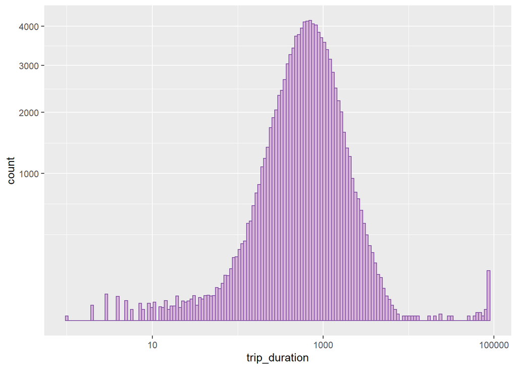

```r
taxitrip_sample %>%
  ggplot(aes(trip_duration)) +
  geom_histogram(color = "#8856a7",fill = "#d7b5d8", bins = 150) +
  scale_x_log10() +
  scale_y_sqrt()
```

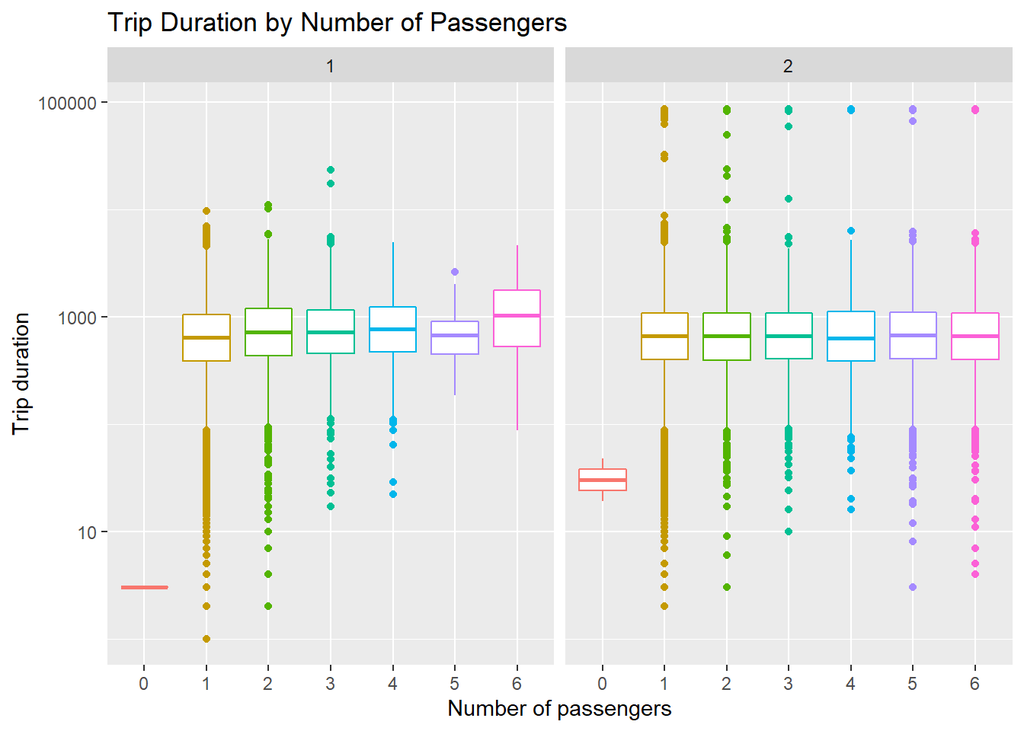

```r
ggplot(taxitrip_sample,aes(as.factor(passenger_count), trip_duration, color = passenger_count))+
geom_boxplot() +
    scale_y_log10() +
  facet_wrap(~ vendor_id) +
    theme(legend.position = "none") +
    labs(title = "Trip Duration by Number of Passengers", x = "Number of passengers",y= "Trip duration")
```

```r
weather.Data <-
  riem_measures(station = "NYC", date_start = "2016-01-01", date_end = "2016-06-30")

weather.Data.clean <- weather.Data%>%
  dplyr::select(valid, tmpf, p01i, sknt)%>%
  replace(is.na(.), 0) %>%
    mutate(interval60 = ymd_h(substr(valid,1,13))) %>%
    mutate(week = week(interval60),
           dotw = lubridate::wday(interval60, label=TRUE)) %>%
    group_by(interval60) %>%
    summarize(Temperature = max(tmpf),
              Precipitation = sum(p01i),
              Wind_Speed = max(sknt)) %>%
    mutate(Temperature = ifelse(Temperature == 0, 42, Temperature))
```